# SI608 Fall 2025 – Homework 1

**Due:** Wednesday, September 24, 12:00PM EST (noon the day before class)

**Instructions:** Please submit your **.ipynb** and **.html** files and **a text file** including your genAI chat history related to this homework via canvas. Remember to rename the notebook by filling in your uniqname. If you have *additional* supplementary files (e.g., images), please also attach them in your submission.

**Collaboration policy:** You may work with others on this but specific answers need to be your own. Please indicate with whom you worked when you turn in this assignment.

## **Question 1 |** Real world networks

*[[10 points]]*

Go to the site http://snap.stanford.edu/data/. **Select two datasets which describe a network.** For each dataset, list both the url and the title.

1. What do the nodes represent?
2. What do the edges represent?
3. Is the graph directed? Weighted? Signed? Bi-partite?

**Dataset 1:**

Dataset title: ego-Facebook

Dataset URL: https://snap.stanford.edu/data/ego-Facebook.html

1. The nodes represent Facebook users.
2. The edges represent connects between users.
3. The graph is undirected.

**Dataset 2:**

Dataset title: wiki-Vote

Dataset URL: https://snap.stanford.edu/data/wiki-Vote.html

1. The nodes represent users participating in the elections
2. The edge from node $i$ to node $j$ represents that user $i$ voted for user $j$.
3. The graph is directed.

## **Question 2 |** Network basics

*[[10 points]]*

Below is an undirected network with nine vertices.

[figure not shown]

### **Q2.1 |** Find the degree of nodes 3 and 7

*[[1 point]]*

- The degree of nodes 3: **3**
- The degree of nodes 7: **5**

### **Q2.2 |** Write down the degree sequence of this network in descending order

*[[1 point]]*

[5, 5, 3, 2, 1, 1, 1, 1, 1]

### **Q2.3 |** Represent this network with an adjacency matrix

*[[2 points]]*

$$ \begin{bmatrix} 0 & 0 & 1 & 0 & 0 & 0 & 0 & 0 & 0 \\ 0 & 0 & 0 & 1 & 0 & 0 & 0 & 0 & 0 \\ 0 & 0 & 0 & 1 & 0 & 0 & 1 & 0 & 0 \\ 0 & 1 & 1 & 0 & 1 & 0 & 1 & 1 & 0 \\ 0 & 0 & 0 & 1 & 0 & 0 & 1 & 0 & 1 \\ 0 & 0 & 0 & 0 & 0 & 0 & 1 & 0 & 0 \\ 0 & 0 & 1 & 1 & 1 & 1 & 0 & 0 & 1 \\ 0 & 0 & 0 & 1 & 0 & 0 & 0 & 0 & 0 \\ 0 & 0 & 0 & 0 & 0 & 0 & 1 & 0 & 0 \end{bmatrix} $$

### **Q2.4 |** Represent this network using an adjacency list

*[[2 points]]*

1: 3  
2: 4  
3: 4, 7  
4: 2, 3, 5, 7, 8  
5: 4, 7  
6: 7  
7: 3, 4, 5, 6, 9  
8: 4  
9: 7

### **Q2.5 |** List the vertices that would make the network unconnected upon deletion

*[[2 points]]*

3, 4, 7

### **Q2.6 |** Determine the minimum number of edges you must remove so that the resulting graph is a tree

*[[2 points]]*

List which edges should be deleted.

Please note that there are multiple correct answers.

- Minium number of edges: 2
- Edges that could be removed
  - 3-7, 5-7
  - 3-4, 4-7
  - 4-7, 4-5
  - 3-7, 4-7
  - 4-7, 5-7

### **Q2.7 |** What is the density and the diameter of this network? Explain your answer.

*[[2 points]]*

- density:
  - $e$: 10
  - $e_{max}$: $9 \times (9-1)=72$
  - density = 2*10/72 $\approx$ 0.2778
- diameter: 3

### **Q2.8 |** Calculate the below measures for nodes 3 and 4

*[[8 points]]*

i) closeness,  
ii) normalized closeness,  
iii) betweenness,  
iv) normalized betweenness.

Do not do this using code. Instead, please write out how you arrived at the solution.

- closeness
  - $node_3 = (1+2+1+2+2+1+2+2)^{-1}=\cfrac{1}{13}$
  - $node_4 = (2+1+1+1+2+1+1+2)^{-1}=\cfrac{1}{11}$
- normalized closeness:
  - $node_3 = (\cfrac{13}{9-1})^{-1}=\cfrac{8}{13}$
  - $node_4 = (\cfrac{11}{9-1})^{-1}=\cfrac{8}{11}$
- betweenness:
  - $node_3=7$
    - Shortest paths that have to pass $node_3$: (1,4), (1,7), (1,2), (1,5), (1,8), (1,6), (1,9)
  - $node_4=14$
    - Shortest paths that have to pass $node_4$: (1,5), (1,8), (2,3), (2,5), (2,6), (2,7), (2,8),(2,9), (3,5), (3,8), (5,8), (6,8), (7,8), (8,9)
- normalized betweenness:
  - $\tbinom{9-1}{2}=28$
  - $node_3=\cfrac{7}{28}=0.25$
  - $node_4=\cfrac{14}{28}=0.5$

## **Question 3 |** Centralization

*[[6 points]]*

Centralization describes how evenly centrality is distributed among nodes.

Which of the two networks has a larger centralization - **Network A** or **Network B**? Why?

*Note: Centralization can be computed for different centrality measures - degree, betweenness, etc. Please use degree here.*

[figure not shown]

- Network A has a larger centralization.
  - $Centrality_A=\cfrac{36}{(10-1)\times (10-2)}=0.5$
  - $Centrality_B=\cfrac{10}{(10-1)\times (10-2)}\approx 0.1389$

## **Question 4 |** Prestige

*[[6 points]]*

[figure not shown]

### **Q4.1 |** Label the influence range of nodes 1, 2, 3, and 4 in the graph above

*[[3 points]]*

*Hint: List the nodes in its input domain*

- node 1: [2, 3, 4, 5, 7, 8]
- node 2: [3, 4, 5]
- node 3: []
- node 4: [3]

*[[3 points]]*

## **Question 5 |** Clustering coefficient

*[[20 points]]*

This part will guide you through the steps of the computing clustering coefficient for an undirected, unweighted graph. In practice, we can utilize `NetworkX` to calculate these attributes. Here, however, you will hand-craft your own functions, so that you can see what's going on underneath.

### **Q5.1 |** Read txt file into an undirected graph

*[[5 points]]*

Load `facebook_combined.txt` into networkx. This is an ego-network of Facebook connections retrieved from http://snap.stanford.edu/data/ego-Facebook.html. Friendships on facebook are mutual; therefore all edges here are undirected.

Each line in the txt file represents an undirected edge between two nodes. For example, `0 1` means there is a link between node `0` and node `1`.

*Hint: after collecting all edges from the file, use `add_edges_from` to build the graph.*

Here are the graph statistics, so that you can ensure you constructed the graph correctly:

```
Number of nodes:     4039
Number of edges:     88234
Average degree:      43.6910
Average clustering:  0.6055
```

```python
# YOUR CODE HERE
import networkx as nx
edges = []
with open('facebook_combined.txt', 'r') as f:
    for line in f:
        u, v = map(int, line.strip().split(' '))
        edges.append((u, v))

G = nx.Graph()
G.add_edges_from(edges)

print(f"Number of nodes: {G.number_of_nodes()}")
print(f"Number of edges: {G.number_of_edges()}")

# average degree
# the sum of degree
avg_degree = sum(dict(G.degree).values())/G.number_of_nodes()
print(f"Average degree: {avg_degree:.4f}")

# average clustering
avg_clus = nx.average_clustering(G)
print(f"Average clustering: {avg_clus:.4f}")
```

```
Number of nodes: 4039
Number of edges: 88234
Average degree: 43.6910
Average clustering: 0.6055
```

### **Q5.2 |** Calculate clustering coefficients using NetworkX

*[[5 points]]*

In class, we introduced (local) clustering coefficient as "the probability that two randomly selected friends of a node are friends with each other."

Here's how `NetworkX` operationalizes this...

> For unweighted graphs, the clustering of a node $u$ is the fraction of possible triangles through that node that exist, $c_u = \frac{2T(u)}{deg(u)(deg(u)-1)}$,

where $T(u)$ is the number of triangles through node $u$ and $deg(u)$ is the degree of $u$. -- [networkx documentation](https://networkx.github.io/documentation/stable/reference/algorithms/generated/networkx.algorithms.cluster.clustering.html#networkx.algorithms.cluster.clustering)

`nx.clustering(g)` will return a full dictionary of all clustering coefficients.  
`nx.clustering(g, node)` will return the corresponding clustering coefficient for a specific node.

Now plot the distribution of clustering coefficients for this network.  
*Hint: use `plt.hist()` to generate a histogram.*

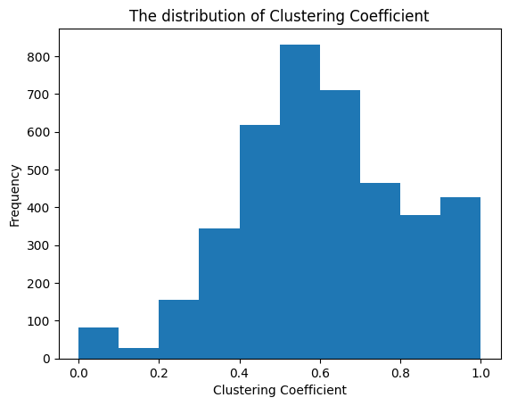

```python
# YOUR CODE HERE
import matplotlib.pyplot as plt

# draw all the clustering coefficients
clus_coef = list(dict(nx.clustering(G)).values())
plt.hist(clus_coef)
plt.title("The distribution of Clustering Coefficient")
plt.xlabel("Clustering Coefficient")
plt.ylabel("Frequency")
plt.show()
```

### **Q5.3 |** Build your own function to calculate clustering coefficients

*[[8 points]]*

Let's now break down how `nx.clustering()` computes the score. The only `NetworkX` function we'll use is `g[node]` (to retrieve the node's neighbor list).

```python
def node_clustering_coeff(g, n):
    # This function should return a clustering coefficient for node n in graph g

    # STEPS:
    # 1. get degree of node n
    # 2. count triangles for node n
    # 3. compute clustering coefficient

    # STEP 1: node degree
    neighbors = set(dict(g[n]).keys()) # YOUR CODE HERE  # collect neighbors for node n (remember to exclude n itself in case there are self-loop links)
    degree = len(neighbors)# YOUR CODE HERE

    # STEP 2: number of triangles
    n_triangles = 0
    for nbr in neighbors:  # interate through each neighbor
        neighbor_nbr = set(dict(g[nbr]).keys())# YOUR CODE HERE  # get neighbors for this neighbor (again, exclude n)
        n_common_nbr = len(neighbors.intersection(neighbor_nbr))# YOUR CODE HERE  # how many of their neighbors is also node n's neighbor?
        # YOUR CODE HERE  # for each set of common neighbors, there's a triangle (double counted)
        n_triangles += n_common_nbr

    # STEP 3: Now compute the clustering coefficient given the triangles you found
    # YOUR CODE HERE
    if degree == 0 or degree == 1:
        clustering_coeff = 0
    else:
        clustering_coeff = 2*n_triangles/(degree*(degree-1))

    return clustering_coeff
```

### **Q5.4 |** Now compute clustering coefficient for each node in the graph, and plot the distribution

*[[2 points]]*

Compare your results with the previous histogram in Q5.2

*Hint: The histograms should be identical.*

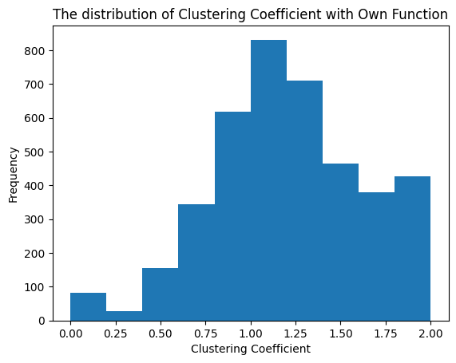

```python
# YOUR CODE HERE
cluster_coeff = []
nodes = G.nodes()
for node in nodes:
    cluster_coeff.append(node_clustering_coeff(G, node))

plt.hist(cluster_coeff)
plt.title("The distribution of Clustering Coefficient with Own Function")
plt.xlabel("Clustering Coefficient")
plt.ylabel("Frequency")
plt.show()
```

## **Question 6 |** Assortativity

*[[16 points]]*

Now we'll look at the Facebook ego network from a different angle.

Recall the concept **assortativity**. It measures "the similarity of connections in the graph with respect to the node degree."  
`NetworkX` also has this shortcut tool for us to compute the assortativity <-- `nx.degree_assortativity_coefficient()`.

### **Q6.1 |** Compute assortativity score for this network

*[[6 points]]*

```python
# YOUR CODE HERE
assort = nx.degree_assortativity_coefficient(G)
print(f"Degree assortativity: {assort:.4f}")
```

```
Degree assortativity: 0.0636
```

### **Q6.2 |** What does the score imply about this friendship network?

*[[5 points]]*

Explain simply in plain English

The assortativity of friendship is positive and smaller than 0.1. This shows a subtle tendency for people with many friends to connect with people who also have many friends, and similarly for those with fewer friends. But, as the coefficent is very close to 0, the effect is very weak.

### **Q6.3 |** Social networks and tech networks

*[[5 points]]*

Below is the degree assortativity scores of various real-world networks (Newman, 2003). In your own words, please explain why social networks are mostly assortative while World Wide Web and Internet are disassortative.

You can find Newman's paper here: https://arxiv.org/pdf/cond-mat/0209450.pdf

[figure not shown]

Social networks are mostly assortative because people with many friends (or collaborators) tend to connect with others who are also highly connected, while those with few connections link with similarly less connected peers. In contrast, technological networks such as the Internet or WWW are disassortative because their structure is hub-and-spoke: high-degree nodes (hubs) connect mainly to low-degree nodes, producing negative assortativity.

## **Question 7 |** Prestige

*[[12 points]]*

For this problem you will need the file "sj.gml". It is a modified file from this dataset: http://vlado.fmf.uni-lj.si/pub/networks/data/esna/SanJuanSur.htm

Essentially, visits between families in a particular village were tracked. Based on the number of visits, each household was assigned a “status score” ranging from 1 to 14. (There is also a leadership nomination field, but we’ll ignore that for now.) For this question, please find which centrality metric best correlates to the status score.

### **Q7.1 |** Load the gml file into networkx

*[[1 point]]*

```python
# YOUR CODE HERE
S = nx.read_gml("sj.gml")
```

[output not shown]

### **Q7.2 |** Calculate in-degree, out-degree, degree, closeness, and betweenness centrality for this network

*[[5 points]]*

```python
# YOUR CODE HERE

# in-degree
in_degree = S.in_degree()
# print(f"In-degree: {in_degree}")

# out-degree
out_degree = S.out_degree()
# print(f"Out-degree: {out_degree}")

# degree
degree = S.degree()
# print(f"Total degree: {degree}")

# closeness
closeness = nx.closeness_centrality(S)
# closeness_fmt = {node: f"{val:.4f}" for node, val in closeness.items()}
# print(f"Closeness centrality: {closeness_fmt}")

# betweenness
betweenness = nx.betweenness_centrality(S, normalized=False)
# betweenness_fmt = {node: f"{val:.1f}" for node, val in betweenness.items()}
# print(f"Betweenness centrality: {betweenness_fmt}")
```

### **Q7.3 |** Calculate additional correlations

*[[4 points]]*

Once you have that, calculate the pearson or spearman correlation between the status field and the centrality measures you computed (you will have 5 correlation measures). This isn’t strictly “kosher” from the stats point of view, but it’ll do for now. Report the correlation and p-values. Happily, Python will do most of the work for you (you can use scipy.stats library for this).

```python
# YOUR CODE HERE
from scipy import stats
import pandas as pd

dict_indeg = dict(S.in_degree())
dict_outdeg = dict(S.out_degree())
dict_deg = dict(S.degree())
dict_closeness = dict(nx.closeness_centrality(S))
dict_between = dict(nx.betweenness_centrality(S))
dict_status = nx.get_node_attributes(S, 'status')

new_data = {
    "in_degree": dict_indeg,
    "out_degree": dict_outdeg,
    "degree": dict_deg,
    "closeness": dict_closeness,
    "betweenness": dict_between,
    "status": dict_status
}

df = pd.DataFrame(new_data)
df.head()

results = []

for col in ["in_degree", "out_degree", "degree", "closeness", "betweenness"]:
    # Pearson correlation
    pearson_r, pearson_p = stats.pearsonr(df["status"], df[col])
    # Spearman correlation
    spearman_r, spearman_p = stats.spearmanr(df["status"], df[col])

    results.append({
        "measure": col,
        "pearson_r": pearson_r,
        "pearson_p": pearson_p,
        "spearman_r": spearman_r,
        "spearman_p": spearman_p
    })

# 整理结果成表格
results_df = pd.DataFrame(results)
print(results_df)
```

```
       measure  pearson_r  pearson_p  spearman_r  spearman_p
0    in_degree   0.350687   0.002038    0.391180    0.000520
1   out_degree   0.170320   0.144033    0.123905    0.289547
2       degree   0.366693   0.001213    0.400072    0.000376
3    closeness   0.264368   0.021907    0.250113    0.030450
4  betweenness   0.048755   0.677856    0.103577    0.376522
```

### **Q7.4 |** What is your intuition as to which measure performed best and which performed worst?

*[[2 points]]*

Based on the results, degree centrality (especially total degree and in-degree) performed the best, since it has the strongest positive correlations with status and statistically significant p-values. In contrast, betweenness centrality performed the worst, as its correlations are very close to zero and not statistically significant.

## **Question 8 |** Centrality measures on Capitol Hill

*[[10 points]]*

For our last question, we are going to work with a Congressional Twitter network dataset - which captures retweeting, replies, mentioned, and quote tweeting behavior among Congressional members.

You can learn more about the network here: https://pmc.ncbi.nlm.nih.gov/articles/PMC10493874/

*Note: For this problem, we will use the 'probabilities of influence' edge weights that the researchers provide in this dataset.*

To begin working with this data:

- Navigate to the Zenodo site, which hosts the dataset: https://zenodo.org/records/8253486
- Download the zip folder titled gsprint23/CongressionalTwitterNetwork-v1.zip
- From this zip folder, find the files titled: congress.edgelist and congress_network_data.json
- To learn about how this data structure captures Twitter interactions, read the section titled **''2. Data Description''** on https://pmc.ncbi.nlm.nih.gov/articles/PMC10493874/
- To complete the below questions, you'll need to work with the two files:
  - congress.edgelist, which contains the **probabilities of influence edge weights**
  - congress_network_data.json, which contains the **inList**, **outList** and **usernameList** lists

### **Q8.1 |** Construct a directed network of Congress members and report basic network characteristics

*[[3 points]]*

Construct a *directed* network using the congress.edgelist file. Nodes represent congresspeople and edges represent a presence of some Twitter interaction (tweets, replies, etc.). The edgeweights represent the 'probablilities of influence' which the researchers calculated.

Report the following simple network characteristics: order (number of nodes), size (number of edges), the diameter, and density.

*Hint: To read in the congress.edgelist file, look at this networkx documentation: https://networkx.org/documentation/stable/reference/readwrite/edgelist.html*

```python
# YOUR CODE HERE
C = nx.read_edgelist("congress.edgelist",
                     create_using=nx.DiGraph(),
                     nodetype=int)

num_nodes = C.number_of_nodes()
num_edges = C.number_of_edges()
density = nx.density(C)

if nx.is_strongly_connected(C):
    diameter = nx.diameter(C)
else:
    largest_cc = max(nx.weakly_connected_components(C), key=len)
    C_lcc = G.subgraph(largest_cc)
    diameter = nx.diameter(C_lcc)

print(f"Number of nodes: {num_nodes}")
print(f"Number of edges: {num_edges}")
print(f"Density: {density:.4f}")
print(f"Diameter: {diameter}")
```

```
Number of nodes: 475
Number of edges: 13289
Density: 0.0590
Diameter: 4
```

### **Q8.2 |** Compute centrality measures and the correlation among them. Interpret the results

*[[3 points]]*

With the directed graph you have just created, compute the degree, betweenness and closeness centrality scores for each node

Then compute the correlation among theses 3 centrality measures, and interpret the results

```python
# YOUR CODE HERE
import pandas as pd
deg_cent = nx.degree_centrality(C)
bet_cent = nx.betweenness_centrality(C)
clo_cent = nx.closeness_centrality(C)

# 组装成 DataFrame
df = pd.DataFrame({
    "degree": pd.Series(deg_cent),
    "betweenness": pd.Series(bet_cent),
    "closeness": pd.Series(clo_cent)
})

# 计算相关性 (Pearson correlation matrix)
corr = df.corr(method="pearson")
print(corr)
```

```
               degree  betweenness  closeness
degree       1.000000     0.822089   0.606846
betweenness  0.822089     1.000000   0.411650
closeness    0.606846     0.411650   1.000000
```

The results show that degree and betweenness centrality are highly correlated (0.82), meaning members with many connections also tend to serve as bridges in the network. Degree and closeness have a moderate correlation (0.61), so well-connected members are generally closer to others. Betweenness and closeness are only weakly correlated (0.41), suggesting that acting as a bridge and being close to all others capture different roles in the network.

### **Q8.3 |** Find the top 10 nodes (i.e. congresspeople) for each centrality measure

*[[3 points]]*

Note: Don't just print the node id, also print the Twitter handle. You'll have to work with the congress_network_data.json file, specifically the **usernameList** that is stored there

If you are curious (or if the twitter handle is unclear), you can also use the look-up tool (https://tweethunter.io/twitter-id-converter) to match congresspeople with their Twitter handles.

```python
# # YOUR CODE
import json
with open("congress_network_data.json", "r") as f:
    data = json.load(f)
usernameList = data[0]["usernameList"]

# ---- Degree centrality ----
degree = nx.degree_centrality(C)
top10_degree = sorted(degree.items(), key=lambda x: x[1], reverse=True)[:10]
print("\nTop 10 by Degree Centrality:")
for node, score in top10_degree:
    print(f"Node {node:4d} | {usernameList[node]:20s} | Score: {score:.4f}")

# ---- Betweenness centrality ----
betweenness = nx.betweenness_centrality(C)
top10_betweenness = sorted(betweenness.items(), key=lambda x: x[1], reverse=True)[:10]
print("\nTop 10 by Betweenness Centrality:")
for node, score in top10_betweenness:
    print(f"Node {node:4d} | {usernameList[node]:20s} | Score: {score:.4f}")

# ---- Closeness centrality ----
closeness = nx.closeness_centrality(C)
top10_closeness = sorted(closeness.items(), key=lambda x: x[1], reverse=True)[:10]
print("\nTop 10 by Closeness Centrality:")
for node, score in top10_closeness:
    print(f"Node {node:4d} | {usernameList[node]:20s} | Score: {score:.4f}")
```

```
Top 10 by Degree Centrality:
Node  322 | GOPLeader            | Score: 0.5992
Node  367 | SpeakerPelosi        | Score: 0.5506
Node  393 | RepBobbyRush         | Score: 0.4008
Node  254 | LeaderHoyer          | Score: 0.3945
Node  208 | RepFranklin          | Score: 0.3840
Node  303 | RepAndyLevin         | Score: 0.3439
Node  269 | RepMikeJohnson       | Score: 0.3439
Node  190 | RepJeffDuncan        | Score: 0.3312
Node  399 | SteveScalise         | Score: 0.3207
Node  111 | RepDonBeyer          | Score: 0.3122

Top 10 by Betweenness Centrality:
Node  322 | GOPLeader            | Score: 0.0730
Node  367 | SpeakerPelosi        | Score: 0.0414
Node  254 | LeaderHoyer          | Score: 0.0307
Node  393 | RepBobbyRush         | Score: 0.0272
Node  335 | RepMMM               | Score: 0.0178
Node  208 | RepFranklin          | Score: 0.0169
Node   17 | JohnCornyn           | Score: 0.0165
Node  303 | RepAndyLevin         | Score: 0.0155
Node  461 | RepBonnie            | Score: 0.0143
Node  113 | RepAndyBiggsAZ       | Score: 0.0127

Top 10 by Closeness Centrality:
Node  322 | GOPLeader            | Score: 0.5616
Node  111 | RepDonBeyer          | Score: 0.5537
Node  208 | RepFranklin          | Score: 0.5473
Node  335 | RepMMM               | Score: 0.5417
Node  269 | RepMikeJohnson       | Score: 0.5356
Node   92 | RepAdams             | Score: 0.5344
Node  188 | RepDonaldsPress      | Score: 0.5314
Node  461 | RepBonnie            | Score: 0.5314
Node  192 | RepTomEmmer          | Score: 0.5308
Node  389 | RepChipRoy           | Score: 0.5284
```

### **Q8.4 |** What if we filtered this graph based on top influencers?

*[[3 points]]*

Repeat the graph construction using congress.edgelist. The network is still directed.

This time, however, for a given node, **keep only the top 3 nodes that are most likely to influence that node**. Remember that the edge weights represent this 'probability of influence' score.

*Hint: Think of the dining.net graph from Lab 2, where students picked their top two dining mates. We are making a similar graph here, where the Congresspeople select the top people that influence them.*

With this new graph, find the answers to Q8.1-Q8.3. (I.e., report basic network measures, recompute the centrality measures and the correlations, and find the top 10 nodes for each measure. Interpret what you are seeing)

```python
# YOUR CODE HERE

N = nx.DiGraph()

for node in C.nodes():
    in_edges = [(u, v, d['weight']) for u, v, d in C.in_edges(node, data=True)]
    top_edges = sorted(in_edges, key=lambda x: x[2], reverse=True)[:3]
    N.add_weighted_edges_from(top_edges)

# 8.1
print("=======Basic Characteristics=======")
print("Filtered graph N:")
print(f"Nodes: {N.number_of_nodes()}")
print(f"Edges: {N.number_of_edges()}")
print(f"Density: {nx.density(N)}")
print("\n")

# 8.2
deg_cent_new = nx.degree_centrality(N)
bet_cent_new = nx.betweenness_centrality(N)
clo_cent_new = nx.closeness_centrality(N)

df = pd.DataFrame({
    "degree": pd.Series(deg_cent_new),
    "betweenness": pd.Series(bet_cent_new),
    "closeness": pd.Series(clo_cent_new)
})

# 计算相关性 (Pearson correlation matrix)
corr_new = df.corr(method="pearson")
print("=======Centrality Correlation=======")
print(corr_new)
print("\n")

# 8.3
# ---- Degree centrality ----
print("=======New Top10 Influencers=======")
degree_new = nx.degree_centrality(N)
top10_degree_new = sorted(degree_new.items(), key=lambda x: x[1], reverse=True)[:10]
print("\nTop 10 by Degree Centrality:")
for node, score in top10_degree_new:
    print(f"Node {node:4d} | {usernameList[node]:20s} | Score: {score:.4f}")

# ---- Betweenness centrality ----
betweenness_new = nx.betweenness_centrality(N)
top10_betweenness_new = sorted(betweenness_new.items(), key=lambda x: x[1], reverse=True)[:10]
print("\nTop 10 by Betweenness Centrality:")
for node, score in top10_betweenness_new:
    print(f"Node {node:4d} | {usernameList[node]:20s} | Score: {score:.4f}")

# ---- Closeness centrality ----
closeness_new = nx.closeness_centrality(N)
top10_closeness_new = sorted(closeness_new.items(), key=lambda x: x[1], reverse=True)[:10]
print("\nTop 10 by Closeness Centrality:")
for node, score in top10_closeness_new:
    print(f"Node {node:4d} | {usernameList[node]:20s} | Score: {score:.4f}")
```

```
=======Basic Characteristics=======
Filtered graph N:
Nodes: 471
Edges: 1399
Density: 0.006319736188282062


=======Centrality Correlation=======
               degree  betweenness  closeness
degree       1.000000     0.748064  -0.134581
betweenness  0.748064     1.000000   0.053789
closeness   -0.134581     0.053789   1.000000


=======New Top10 Influencers=======

Top 10 by Degree Centrality:
Node  399 | SteveScalise         | Score: 0.0660
Node  393 | RepBobbyRush         | Score: 0.0574
Node  470 | RepJoeWilson         | Score: 0.0489
Node  367 | SpeakerPelosi        | Score: 0.0447
Node  436 | RepMarkTakano        | Score: 0.0426
Node  321 | RepLucyMcBath        | Score: 0.0426
Node  322 | GOPLeader            | Score: 0.0426
Node  264 | RepJeffries          | Score: 0.0404
Node  135 | RepCori              | Score: 0.0340
Node  129 | VernBuchanan         | Score: 0.0340

Top 10 by Betweenness Centrality:
Node  436 | RepMarkTakano        | Score: 0.0644
Node  470 | RepJoeWilson         | Score: 0.0495
Node  208 | RepFranklin          | Score: 0.0463
Node  135 | RepCori              | Score: 0.0449
Node  399 | SteveScalise         | Score: 0.0423
Node   56 | JerryMoran           | Score: 0.0416
Node   49 | SenMikeLee           | Score: 0.0363
Node  393 | RepBobbyRush         | Score: 0.0342
Node   19 | SenTomCotton         | Score: 0.0341
Node   82 | SenToomey            | Score: 0.0339

Top 10 by Closeness Centrality:
Node  474 | RepLeeZeldin         | Score: 0.1244
Node  182 | RepValDemings        | Score: 0.1206
Node  427 | RepSteel             | Score: 0.1190
Node  412 | RepSherrill          | Score: 0.1190
Node  203 | RepChuck             | Score: 0.1189
Node  425 | RepGregStanton       | Score: 0.1188
Node  473 | RepJohnYarmuth       | Score: 0.1188
Node  304 | RepMikeLevin         | Score: 0.1186
Node  177 | RepPeterDeFazio      | Score: 0.1184
Node  267 | RepEBJ               | Score: 0.1184
```